# Web Mining and Applied NLP (CSIS 44-620)

## P3: Employ Matplotlib, Pyplot & Engage

Author: Data-Git-Hub  
GitHub Project Repository Link: https://github.com/Data-Git-Hub/Pyplot  
6 July 2025

### Introduction

This project demonstrates foundational data visualization techniques using Python’s Matplotlib library, specifically the pyplot module. Through a series of guided tasks, I create and compare different types of visual charts—including scatter plots and line plots—by generating random data points with Python's random module or NumPy. These visualizations help reinforce core concepts in chart construction, data presentation, and the customization options available in Matplotlib. The project is executed in a Jupyter Notebook environment, using clean code and Markdown headings to document each step and response. The goal is to build both technical fluency in Matplotlib and an understanding of how to effectively present data in a visual format that is clear, accurate, and engaging.

### Imports

Python libraries are collections of pre-written code that provide specific functionalities, making programming more efficient and reducing the need to write code from scratch. These libraries cover a wide range of applications, including data analysis, machine learning, web development, and automation. Some libraries, such as os, sys, math, json, and datetime, come built-in with Python as part of its standard library, providing essential functions for file handling, system operations, mathematical computations, and data serialization. Other popular third-party libraries, like pandas, numpy, matplotlib, seaborn, and scikit-learn, must be installed separately and are widely used in data science and machine learning. The extensive availability of libraries in Python's ecosystem makes it a versatile and powerful programming language for various domains.

Matplotlib is a widely used data visualization library that allows users to create static, animated, and interactive plots. It provides extensive tools for generating various chart types, including line plots, scatter plots, histograms, and bar charts, making it a critical library for exploratory data analysis.  
https://matplotlib.org/stable/contents.html

```python
# Imports

# Visualization libraries
import matplotlib.pyplot as plt
```

### Tasks

Perform the tasks described in the Markdown cells below. When you have completed the assignment make sure your code cells have all been run (and have output beneath them) and ensure you have committed and pushed ALL of your changes to your assignment repository.

Every question that requires you to write code will have a code cell underneath it; you may either write your entire solution in that cell or write it in a python file (`.py`), then import and run the appropriate code to answer the question.

Do not use other external modules except `matplotlib` and `pyplot` (e.g. `math`, etc) for this assignment unless you are explicitly instructed to, though you may use built in python functions (`min`, `max`, etc) as you wish.

For all of these questions, your plots must have an appropriate title and labeled axes. Use the Matplotlib documentation as necessary to guide you through these exercises.

#### Section 1. Character Frequency Visualization

Given the text below, create a bar plot (or a horizontal bar plot) that shows the frequency distribution of characters in the string.  
A dictionary has been created for you containing the characters and the frequencies of the characters.  
Make sure your bar plot has the bars labelled correctly (with the character it represents the frequency of).

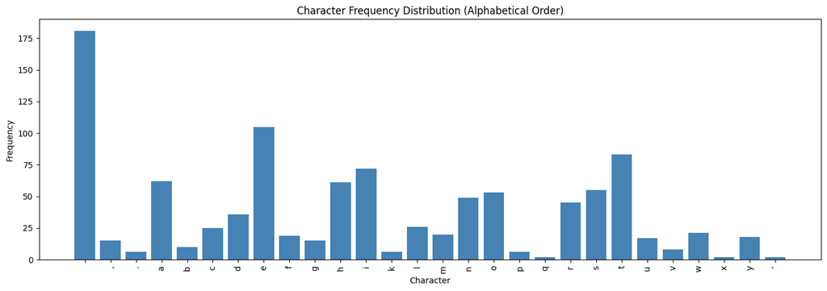

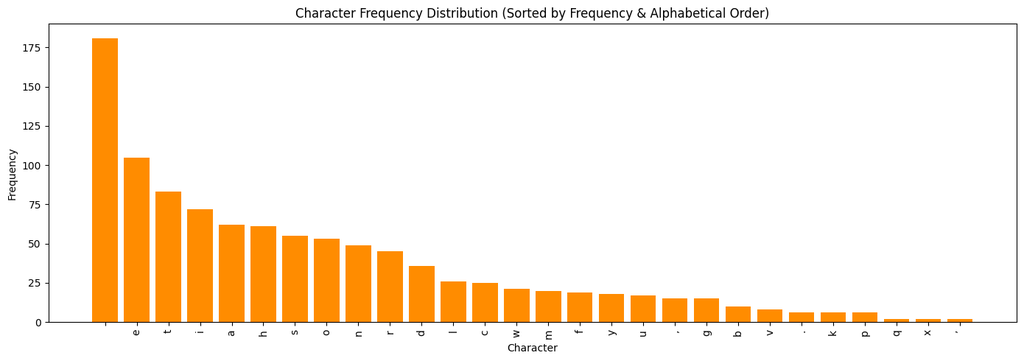

```python
from collections import Counter
TEXT = "At three o’clock precisely I was at Baker Street, but Holmes had not yet returned. The landlady informed me that he had left the house shortly after eight o’clock in the morning. I sat down beside the fire, however, with the intention of awaiting him, however long he might be. I was already deeply interested in his inquiry, for, though it was surrounded by none of the grim and strange features which were associated with the two crimes which I have already recorded, still, the nature of the case and the exalted station of his client gave it a character of its own. Indeed, apart from the nature of the investigation which my friend had on hand, there was something in his masterly grasp of a situation, and his keen, incisive reasoning, which made it a pleasure to me to study his system of work, and to follow the quick, subtle methods by which he disentangled the most inextricable mysteries. So accustomed was I to his invariable success that the very possibility of his failing had ceased to enter into my head.".lower()
letter_freq = dict(Counter(TEXT))

# make a bar plot with an appropriate title, correct xtick labels, and labeled axes

# Bar Plot 1: Character frequencies sorted alphabetically
sorted_alpha = dict(sorted(letter_freq.items(), key=lambda x: x[0]))

plt.figure(figsize=(14, 5))
plt.bar(sorted_alpha.keys(), sorted_alpha.values(), color='steelblue')
plt.title("Character Frequency Distribution (Alphabetical Order)")
plt.xlabel("Character")
plt.ylabel("Frequency")
plt.xticks(rotation=90)
plt.tight_layout()
plt.show()

# Bar Plot 2: Sorted by frequency (descending), then alphabetically
sorted_freq = sorted(letter_freq.items(), key=lambda x: (-x[1], x[0]))

plt.figure(figsize=(14, 5))
plt.bar([char for char, _ in sorted_freq], [count for _, count in sorted_freq], color='darkorange')
plt.title("Character Frequency Distribution (Sorted by Frequency & Alphabetical Order)")
plt.xlabel("Character")
plt.ylabel("Frequency")
plt.xticks(rotation=90)
plt.tight_layout()
plt.show()
```

#### Section 2. Visualizing a Sequence of Random Prime Numbers

Generate a sequence of at least 5 random numbers (integers are fine), and visualize the data using both `scatter` and `plot` on different axes. You may use the index of the value as its x value in the plot.

```
Randomly selected prime numbers (unordered):
[59, 181, 193, 167, 71, 11, 19, 43, 101, 23, 29, 191, 17]
```

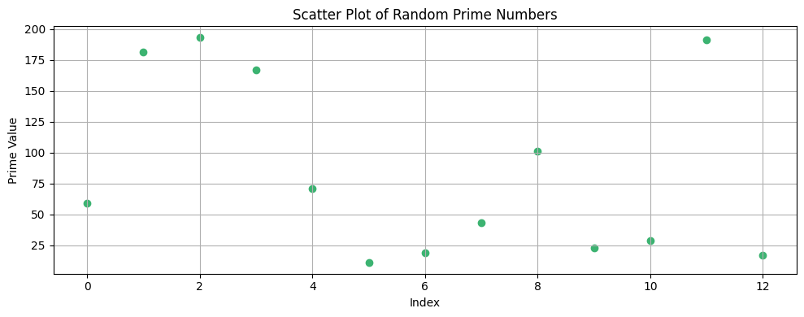

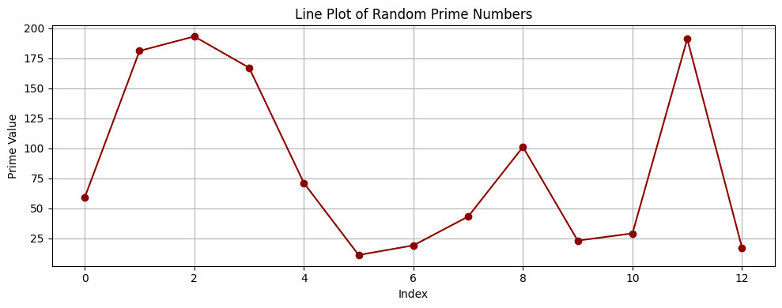

```python
from random import sample

# Define all prime numbers between 2 and 199
def is_prime(n):
    if n < 2:
        return False
    for i in range(2, int(n**0.5)+1):
        if n % i == 0:
            return False
    return True

primes = [n for n in range(2, 200) if is_prime(n)]

# Select 13 unique random primes
random_primes = sample(primes, 13)

# Print the selected primes
print("Randomly selected prime numbers (unordered):")
print(random_primes)

# Create x values as indices
x_values = list(range(len(random_primes)))

# Scatter Plot
plt.figure(figsize=(10, 4))
plt.scatter(x_values, random_primes, color='mediumseagreen')
plt.title("Scatter Plot of Random Prime Numbers")
plt.xlabel("Index")
plt.ylabel("Prime Value")
plt.grid(True)
plt.tight_layout()
plt.show()

# Line Plot
plt.figure(figsize=(10, 4))
plt.plot(x_values, random_primes, marker='o', linestyle='-', color='darkred')
plt.title("Line Plot of Random Prime Numbers")
plt.xlabel("Index")
plt.ylabel("Prime Value")
plt.grid(True)
plt.tight_layout()
plt.show()
```

#### Section 3. Restyled Scatter and Line Plots of Random Prime Numbers

Do the same question as above, but change the style and color of both the scatter and the plot.

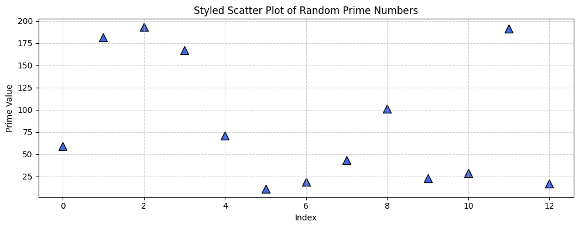

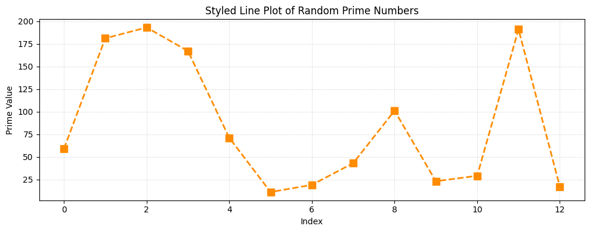

```python
# Reuse the same data from Section 2
# Ensure random_primes and x_values are already defined

# Styled Scatter Plot
plt.figure(figsize=(10, 4))
plt.scatter(x_values, random_primes, color='royalblue', marker='^', s=100, edgecolors='black')
plt.title("Styled Scatter Plot of Random Prime Numbers")
plt.xlabel("Index")
plt.ylabel("Prime Value")
plt.grid(True, linestyle='--', alpha=0.6)
plt.tight_layout()
plt.show()

# Styled Line Plot
plt.figure(figsize=(10, 4))
plt.plot(x_values, random_primes, color='darkorange', linestyle='--', marker='s', markersize=8, linewidth=2)
plt.title("Styled Line Plot of Random Prime Numbers")
plt.xlabel("Index")
plt.ylabel("Prime Value")
plt.grid(True, linestyle=':', alpha=0.6)
plt.tight_layout()
plt.show()
```

#### Section 4. Comparing Sorting Algorithm Performance

Given the data sets below, plot or scatter both on the same set of axes. You are plotting the time it takes to execute a sorting algorithm on a list of a given size; your x axis should be the size, and the y axis is time. Assume that `insertion_sort_times[i]` is how long it took to sort a list of length `sizes[i]`. Add a legend to your plot showing which is insertion sort and which is merge sort. Use the variable names to determine which data is which.

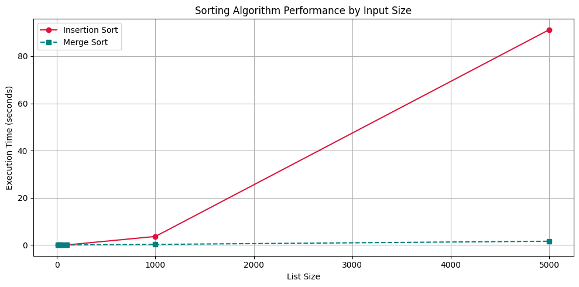

```python
# Given data
sizes = [10, 20, 50, 100, 1000, 5000]
insertion_sort_times = [0.0010252999999999998, 0.0027026999999999954, 0.010147200000000002, 0.0381137, 3.6303399, 91.2180796]
merge_sort_times = [0.00161889999999687, 0.003635600000009731, 0.0090655000000055, 0.020108000000007564, 0.2687474000000094, 1.6147050999999948]

# Plot both on the same axes
plt.figure(figsize=(10, 5))
plt.plot(sizes, insertion_sort_times, marker='o', linestyle='-', color='crimson', label='Insertion Sort')
plt.plot(sizes, merge_sort_times, marker='s', linestyle='--', color='teal', label='Merge Sort')

# Add labels, legend, and grid
plt.title("Sorting Algorithm Performance by Input Size")
plt.xlabel("List Size")
plt.ylabel("Execution Time (seconds)")
plt.legend()
plt.grid(True)
plt.tight_layout()
plt.show()
```